# Report Exercise: Phenology Modelling

Tino Schneidewind

```r
# Libraries
library(phenocamr);library(geodata);library(terra);library(dplyr);library(here)
library(ggplot2);library(patchwork);library(GenSA);library(BayesianTools)
library(daymetr);library(raster);library(MODISTools);library(leaflet);library(tidyterra)
```

### **Introduction**

Phenology is influenced by seasonal and interannual variability in climate. In the age of climate change, we observe changes in biological life cycles with consequences for ecosystem stability and diversity. In this exercise, we modeled the growing degree days (GDD), which describe the temperature accumulation in spring until leaf unfolding. For this, we worked through [“Handful of Pixels” chapter 6](https://geco-bern.github.io/handfull_of_pixels/phenology_modelling.html).

As data, we used PhenoCam data, which we accessed using the [{phenocamr}](https://bluegreen-labs.github.io/phenocamr/) [R package](https://bluegreen-labs.github.io/phenocamr/). We chose the site “harvard” in north eastern USA. The data was downloaded according to chapter 6.2. The used model for GDD and the model optimization method is described in chapter 6.2. After optimizing the model, we have values for the **temperature threshold (2.811523)** and the **number of accumulation days (228.27844)**. Using these values, we were able to predict the growing degree days from 2008-2022 as follows.

```r
# Load data
phenocamr::download_phenocam(
  site = "harvard$",
  veg_type = "DB",
  roi_id = "1000",
  daymet = TRUE,
  phenophase = TRUE,
  trim = 2022,
  out_dir = tempdir())

harvard_phenocam_data <- readr::read_csv(
  file.path(tempdir(), "harvard_DB_1000_3day.csv"),
  comment = "#")
```

```r
# Data processing
harvard_phenology <- readr::read_csv(
  file.path(
    tempdir(),
    "harvard_DB_1000_3day_transition_dates.csv"
    ),
  comment = "#") |>

  dplyr::filter(
    direction == "rising",
    gcc_value == "gcc_90"  )|>
  mutate(
    doy = as.numeric(format(as.Date(transition_25),"%j")),
    year = as.numeric(format(as.Date(transition_25),"%Y"))) |>

  dplyr::select(
    year,
    doy,
    transition_25,
    threshold_25)


harvard_temp <- harvard_phenocam_data |>
  group_by(year) |>
  dplyr::mutate(
    tmean = (tmax..deg.c. + tmin..deg.c.)/2) |>

  dplyr::mutate(
    date = as.Date(date),
    gdd = cumsum(ifelse(tmean >= 5, tmean - 5, 0))) |>

  dplyr::select(
    date,
    year,
    tmean,
    gdd) |>
  ungroup()
```

```r
# Load model functions
source("../functions/phenology_models.R")
```

```r
# starting model parameters
par = c(0, 130)
lower <- c(-10,0)
upper <- c(45,500)

data_harvard <- list(
  drivers = harvard_temp,
  validation = harvard_phenology)

# model optimisation
optim_par_harvard = GenSA::GenSA(
  par = par,
  fn = rmse_gdd,
  lower = lower,
  upper = upper,
  control = list(
    max.call = 4000
  ),
  data = data_harvard
)$par

# model application
predictions_harvard <- harvard_temp |>
  group_by(year) |>
  summarize(
    prediction = gdd_model(
      temp = tmean,
      par = optim_par_harvard)) |>
  drop_na()

print(predictions_harvard)
```

```
## # A tibble: 15 × 2
##     year prediction
##    <dbl>      <int>
##  1  2008        128
##  2  2009        125
##  3  2010        119
##  4  2011        131
##  5  2012        115
##  6  2013        130
##  7  2014        135
##  8  2015        131
##  9  2016        128
## 10  2017        124
## 11  2018        130
## 12  2019        128
## 13  2020        137
## 14  2021        122
## 15  2022        129
```

```r
lm(predictions_harvard$prediction ~ harvard_phenology$doy)$coeff
```

```
##           (Intercept) harvard_phenology$doy
##            33.1303146             0.7459385
```

The modeled leaf unfolding days (DOY) compared to the measured ones look like this:

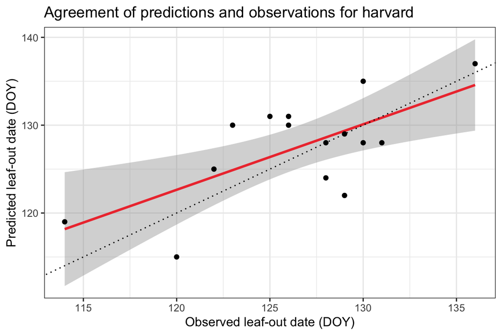

The model and the observed leaf out days had visually had a similar tendency, however, the slope between both was only 0.74 instead of the optimal of 1. The linear model of both datasets was significant with a p-vaule of 0.005 and an R2 of 0.46.

We scaled the model spatially for the year 2010 to compare it later on.

```r
# model application for 2010
prediction_harvard_10 <- harvard_temp |>
  dplyr::filter(
    year == 2010
  ) |>
  group_by(year) |>
  summarize(
    pred = gdd_model(
      temp = tmean,
      par = optim_par_harvard
      )
  )
```

```r
# Download daily data
daymetr::download_daymet_tiles(
  tiles = 11935,
  start = 2010,
  end = 2010,
  param = c("tmin","tmax"),
  path = paste0(here::here(), "/data-raw/"),
  silent = TRUE
  )

# calculate the daily mean values
r <- daymetr::daymet_grid_tmean(
  path = paste0(here::here(), "/data-raw/"),
  product = 11935,
  year = 2010,
  internal = TRUE
)

# reproject to lat lon
r <- terra::project(
  r,
  "+init=epsg:4326"
)

# subset to first 180 days
ma_nh_temp <- terra::subset(
  r,
  1:180
)

predicted_phenology_harvard <- terra::app(
  ma_nh_temp,
  fun = gdd_model,
  par = optim_par_harvard
)
```

[interactive chart not shown]

### **Exercises**

#### **1. Model Optimization**

*Task: How can you improve the model used to regionally scale the results in Chapter 6? Provide at least three ways to improve the model used. Implement at least one of these methods.*

Multiple methods are possible to modify the used model.

1. We could add data **additional training data** in order to improve the model generalisability. I will implement this method further down in this report.
2. It would be possible to improve the model by **adding another parameter** like radiation, humidity or soil propoerties. This would make the model more sensitive to non temperature abiotic factors.
3. Another method to improve the model could be **altering the loss function**, in our case RSME, to a more suitable alternative.
4. Of course, we could implement **machine learning** to improve our predictions, however, this would be considered a change of the model and not an optimization

#### **2. Implementation of Optimization**

In order to ensure some comparibility between the new site and the harvard site, I chose a site nearby. The **worchester** site (lat: 42.2697, lon: -71.8428) is approximately 40 km southeast of the harvard site. Compared to harvard (340 m above sea level), worchester has less elevation (185 m above sea level). This site is also part of the PhenoCam network. Both datasets were given an ID, so that we are able to distinguish between the two sites in the modeling process.

```r
# Load data for worcester
phenocamr::download_phenocam(
  site = "worcester",
  veg_type = "DB",
  roi_id = "1000",
  daymet = TRUE,
  phenophase = TRUE,
  trim = 2022,
  out_dir = tempdir()
)

worcester_phenocam_data <- readr::read_csv(
  file.path(tempdir(), "worcester_DB_1000_3day.csv"),
  comment = "#"
)
```

```r
# Data processing worcester
worcester_phenology <- readr::read_csv(
  file.path(
    tempdir(),
    "worcester_DB_1000_3day_transition_dates.csv"
  ),
  comment = "#"
) |>
  dplyr::filter(
    direction == "rising",
    gcc_value == "gcc_90"
  )

worcester_temp <- worcester_phenocam_data |>
  group_by(year) |>
  dplyr::mutate(
    tmean = (tmax..deg.c. + tmin..deg.c.)/2
  ) |>
  dplyr::mutate(
    date = as.Date(date),
    gdd = cumsum(ifelse(tmean >= 5, tmean - 5, 0))
  ) |>
  dplyr::select(
    date,
    year,
    tmean,
    gdd
  ) |>
  ungroup()

worcester_phenology <- worcester_phenology |>
  dplyr::mutate(
    doy = as.numeric(format(as.Date(transition_25),"%j")),
    year = as.numeric(format(as.Date(transition_25),"%Y"))
  ) |>
  dplyr::select(
    year,
    doy,
    transition_25,
    threshold_25
  )

worcester_temp <- worcester_phenocam_data |>
  group_by(year) |>
  dplyr::mutate(
    tmean = (tmax..deg.c. + tmin..deg.c.)/2
  ) |>
  dplyr::mutate(
    date = as.Date(date),
    gdd = cumsum(ifelse(tmean >= 5, tmean - 5, 0))
  ) |>
  dplyr::select(
    date,
    year,
    tmean,
    gdd
  ) |>
  ungroup()

worcester_phenology <- worcester_phenology |>
  dplyr::mutate(
    doy = as.numeric(format(as.Date(transition_25),"%j")),
    year = as.numeric(format(as.Date(transition_25),"%Y"))
  ) |>
  dplyr::select(
    year,
    doy,
    transition_25,
    threshold_25
  )

# Site ID
worcester_temp$ID <- "worcester"
harvard_temp$ID <- "harvard"
worcester_phenology$ID <- "worcester"
harvard_phenology$ID <- "harvard"
```

```r
# Data merging
data_ha_wo <- list(
  drivers = rbind(worcester_temp, harvard_temp),
  validation = rbind(worcester_phenology, harvard_phenology))

# model optimization on new data
optim_par_ha_wo = GenSA::GenSA(
  par = par,
  fn = rmse_gdd,
  lower = lower,
  upper = upper,
  control = list(
    max.call = 4000
  ),
  data = data_ha_wo
)$par

# model application
predictions_ha_wo <- rbind(worcester_temp, harvard_temp) |>
  group_by(year) |>
  summarize(
    prediction = gdd_model(
      temp = tmean,
      par = optim_par_ha_wo)) |>
  drop_na()

print(predictions_ha_wo)
```

```
## # A tibble: 15 × 2
##     year prediction
##    <dbl>      <int>
##  1  2008        131
##  2  2009        128
##  3  2010        122
##  4  2011        134
##  5  2012        125
##  6  2013         80
##  7  2014        132
##  8  2015        128
##  9  2016        129
## 10  2017        118
## 11  2018        126
## 12  2019        126
## 13  2020        137
## 14  2021        118
## 15  2022        127
```

```r
lm(predictions_ha_wo$prediction ~ harvard_phenology$doy)$coeff
```

```
##           (Intercept) harvard_phenology$doy
##            19.9600760             0.8231939
```

When using both datasets as input, the optimization routine returned different optimal parameters compared to before. The **temperature threshold changed to 5.861427** and the **number of accumulation days to 143.048134**. The optimal parameters changed significantly due to the change in input data. I ran the new model again for all years and got the following scatterplot of my new predictions and the observed leaef unfolding days of harvard.

In this plot you can see, that my improved model has pretty good alignement with the validation data. However, there is the clear outlier, which was predicted in 2013. This outlier did not appear before we adjusted the model by adding the worchester data. The slope of the linear model improved up to 0.82. However, Rquared is now only 0.1 and p = 0.23.

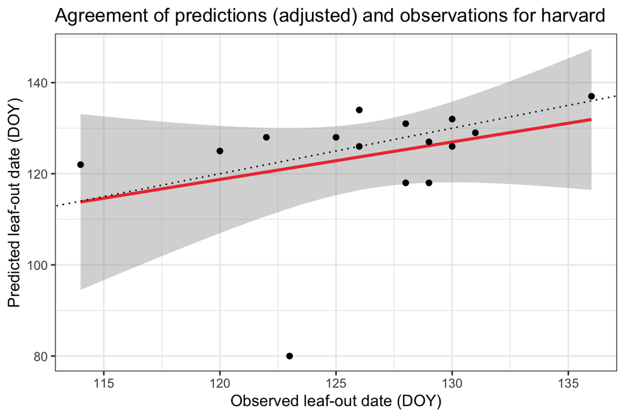

Again, I spatially scaled the model with the new parameters for the year 2010. When comparing this new spatial model to the previous one, it is clear that we reach higher values for DOY. The general pattern is similar with the highest values in the upper left corner and the lowest in the bottom right corner. There is a noticeable change in pattern visible in the changes from purple to yellow and dark purple to purple. This indicates that the new values did not simply increase linearly, but that the change in optimal parameters also influenced the small scale local gradients of the DOY.

```r
# model optimisation for year 2010
prediction_ha_wo_10 <- rbind(worcester_temp, harvard_temp) |>
  dplyr::filter(
    year == 2010
  ) |>
  group_by(year) |>
  summarize(
    pred = gdd_model(
      temp = tmean,
      par = optim_par_ha_wo))

# model optimisation for year 2010
predicted_phenology_ha_wo <- terra::app(
  ma_nh_temp,
  fun = gdd_model,
  par = optim_par_ha_wo)
```

[interactive chart not shown]

#### **3. Statistical Comparison to MODIS Data**

*Task: Statistically compare the results with the MODIS MCD12Q2 phenology product: compare the data spatially, describe why you might or might not see the same patterns, consider that 2010 was a ‘special’ year for the north east of the US.*

```r
# load Modis data for harvard
phenology <- MODISTools::mt_subset(
  product = "MCD12Q2",
  lat = 42.5378,
  lon = -72.1715,
  band = "Greenup.Num_Modes_01",
  start = "2008-01-01",
  end = "2022-12-31",
  km_lr = 20,
  km_ab = 20,
  site_name = "swiss",
  internal = TRUE,
  progress = FALSE
)
```

```r
# Data processing
phenology <- phenology |>
  mutate(
    value = ifelse(value > 32656, NA, value),
    value = as.numeric(format(as.Date("1970-01-01") + value, "%j")),
    value = ifelse (value < 200, value, NA)
  )
phenology_raster <- MODISTools::mt_to_terra(
  phenology,
  reproject = TRUE
)

phenology_filtered <- phenology |>
  dplyr::select(
    value,
    calendar_date
  ) |>
  dplyr::mutate(
    calendar_date = format(as.Date(calendar_date), format = "%Y")
  ) |>
  group_by(calendar_date) |>
  summarize(
    pheno_mean = mean(value, na.rm=T)
  )
```

As we included two sites for our predicition-model, I chose to include data from the other site as well, and calculate an average between the two MODIS data sets. As both sites are further appart than the MODIS raster left to right, this adds new data. We are able to compare both data sets, because we can assume a normal distribution of the yearly mean values, due to the central limit theorem.

```r
# load Modis data for worchester
phenology <- MODISTools::mt_subset(
  product = "MCD12Q2",
  lat = 42.2697,
  lon = -71.8428,
  band = "Greenup.Num_Modes_01",
  start = "2008-01-01",
  end = "2022-12-31",
  km_lr = 20,
  km_ab = 20,
  site_name = "swiss",
  internal = TRUE,
  progress = FALSE
)
```

```r
# Data processing for worcester
phenology <- phenology |>
  mutate(
    value = ifelse(value > 32656, NA, value),
    value = as.numeric(format(as.Date("1970-01-01") + value, "%j")),
    value = ifelse (value < 200, value, NA)
  )
phenology_raster <- MODISTools::mt_to_terra(
  phenology,
  reproject = TRUE
)

phenology_filtered_2 <- phenology |>
  dplyr::select(
    value,
    calendar_date
  ) |>
  dplyr::mutate(
    calendar_date = format(as.Date(calendar_date), format = "%Y")
  ) |>
  group_by(calendar_date) |>
  summarize(
    pheno_mean = mean(value, na.rm=T)
  )

phenology_filtered$mean_2 <- rep(1, length(phenology_filtered$calendar_date))

# averaging between both data sets
for (i in 1:length(phenology_filtered$calendar_date)){
  phenology_filtered$mean_2[i] = mean(c(phenology_filtered$pheno_mean[i], phenology_filtered_2$pheno_mean[i]))
}
```

```r
t.test(predictions_ha_wo$prediction, phenology_filtered$mean_2)
```

```
##
##  Welch Two Sample t-test
##
## data:  predictions_ha_wo$prediction and phenology_filtered$mean_2
## t = 4.8322, df = 17.483, p-value = 0.0001445
## alternative hypothesis: true difference in means is not equal to 0
## 95 percent confidence interval:
##   9.922944 25.246066
## sample estimates:
## mean of x mean of y
##  124.0667  106.4822
```

```
##               (Intercept) phenology_filtered$mean_2
##                72.3310933                 0.4858614
```

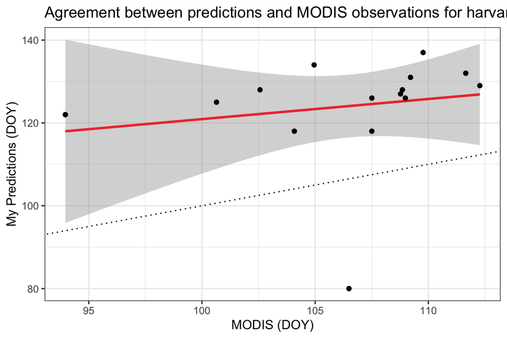

```
## (Intercept)         v$Y
##  75.2858992   0.4876761
```

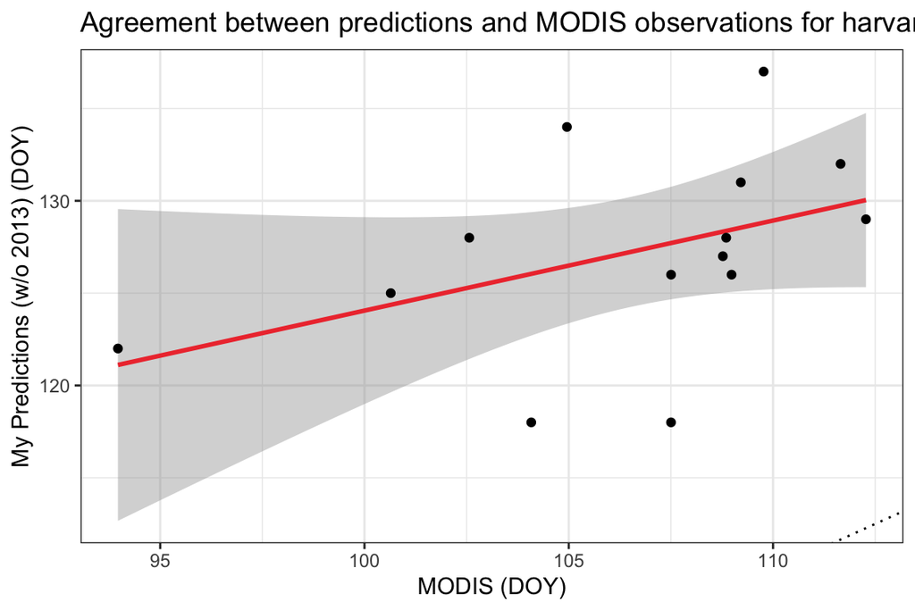

#### **4. Spatial comparison of 2010**

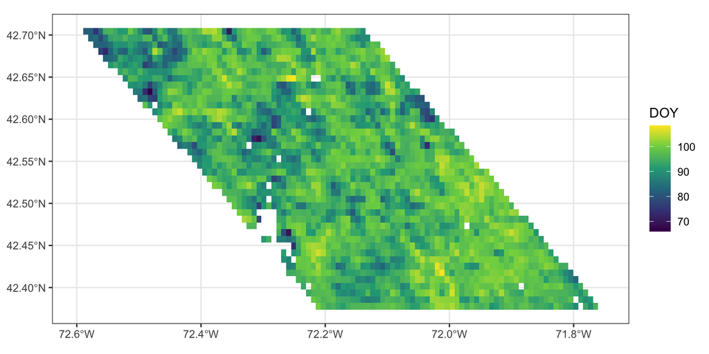

```r
# load Modis data for harvard 2010
phenology <- MODISTools::mt_subset(
  product = "MCD12Q2",
  lat = 42.5378,
  lon = -72.1715,
  band = "Greenup.Num_Modes_01",
  start = "2010-01-01",
  end = "2010-12-31",
  km_lr = 20,
  km_ab = 20,
  site_name = "swiss",
  internal = TRUE,
  progress = FALSE
)

phenology <- phenology |>
  mutate(
    value = ifelse(value > 32656, NA, value),
    value = as.numeric(format(as.Date("1970-01-01") + value, "%j")),
    value = ifelse (value < 200, value, NA))

phenology_raster <- MODISTools::mt_to_terra(
  phenology,
  reproject = TRUE)

ggplot() +
  tidyterra::geom_spatraster(data = phenology_raster) +
  scale_fill_viridis_c(
    na.value = NA,
    name = "DOY"
    ) +
  theme_bw()
```

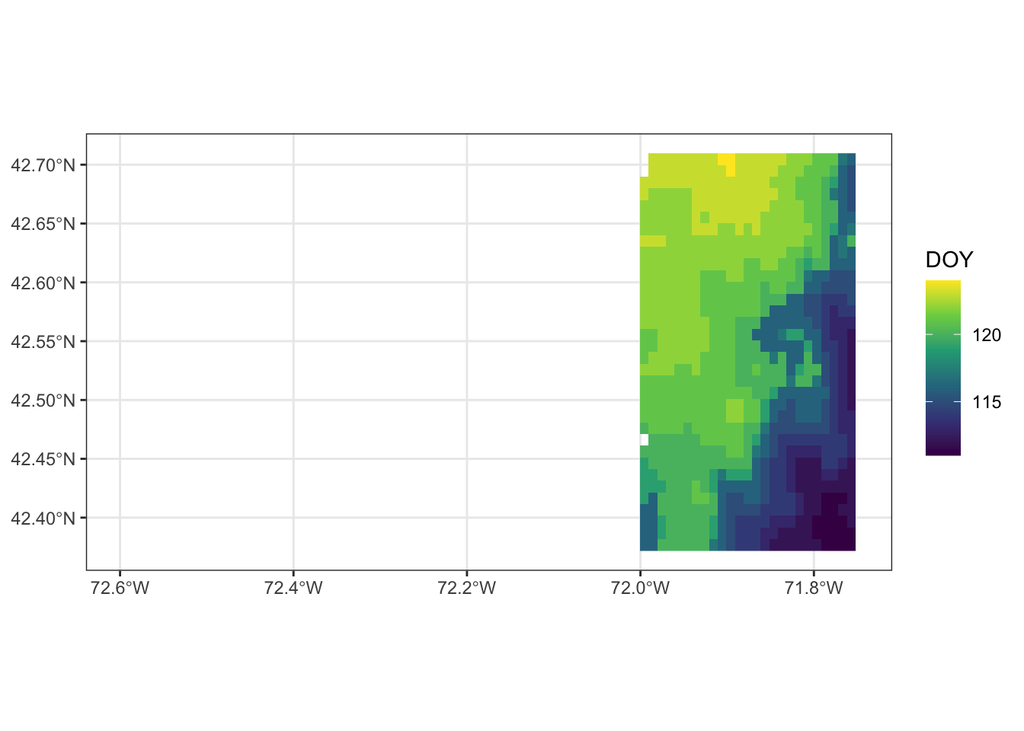

```r
# crop rasters to same size
raster_pred_modis <- crop(predicted_phenology_ha_wo,phenology_raster)

ggplot() +
  tidyterra::geom_spatraster(data = raster_pred_modis) +
  scale_fill_viridis_c(
    na.value = NA,
    name = "DOY"
    ) +
  theme_bw()
```

```r
# resample raster to same geometry
pred_resampled <- terra::resample(raster_pred_modis,phenology_raster)
```

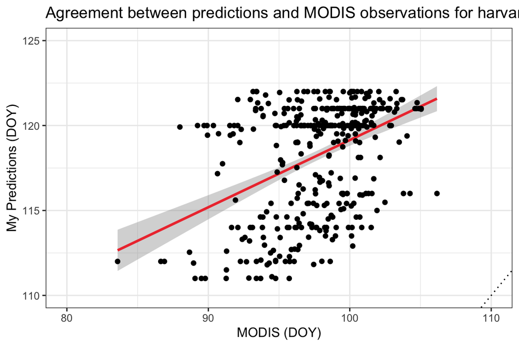

Overall, we saw a poor agreement of the modeled predictions and the observed leaf out dates. This is likely due to 2010 being an extraordinary year in terms of temperature. Average temperature was observed to be slightly above average. Important for our predictions, the winter was abnormally cold and spring record warm ([NCEI USA](https://www.ncei.noaa.gov/access/monitoring/monthly-report/national/201013)). This rapid warming influences the warming days we tried to model, leading to possibly wrong conclusions as the system operates in the extremes.